# Scientific Papers Guidance

## Structure

Finally, they structure the content in the body in theorem-proof fashion, stating first what readers must remember (for example, as the **first sentence** of a paragraph) and then **presenting evidence to support this statement**

### Abstract

Summarize the **motivation** for, and the **outcome** of, the work in an abstract

### Introduction

Clarifies the motivation for the work

- **Context**
  - Provide context to make reader familiar with the topic
  - Establish the importance of the work
- **Need**
  - Research gaps (Current community has vs What it wants)
    - If too many about literatures, add new section **"State of the art"**
  - Compelling Motivation
    - Anchor by time and space
  - e.g. To form a better view of the global distribution and infectiousness of this pathogen, we examined 1645 postmetamorphic and adult amphibians collected from 27 countries between 1984 and 2006 for the presence of . . .
- **Task**
  - How to address the need
  - Clarifies your contribution
  - e.g. To confirm this assumption, we studied the effects of a range of inhibitors of connexin channels, such as the connexin mimetic peptides Gap26 and Gap27 and anti-peptide antibodies, on calcium signaling in cardiac cells and HeLa cells expressing connexins.
- **Object**
  - Preview the remainder of the paper
  - e.g. This paper clarifies the role of CxHc on calcium oscillations in neonatal cardiac myocytes and calcium transients induced by ATP in HL-cells originated from cardiac atrium and in HeLa cells expressing connexin 43 or 26.

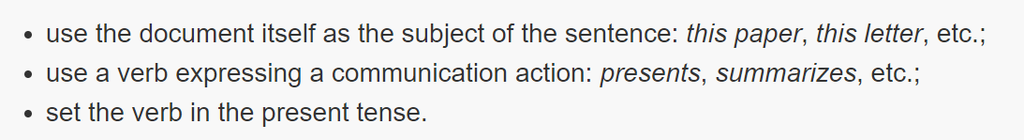

### Materials and Methods (changeable for new method paper)

Provides sufficient detail for other scientists to reproduce the experiments presented in the paper.

### Results and Discussion (changeable for new method paper)

- Present and discuss the research results
- **State the message of each paragraph upfront**: Convey in the first sentence what you want readers to remember from the paragraph as a whole.

### Conclusion

- Presents the outcome of the work by **interpreting the findings at a higher level** of abstraction than the Discussion
- **Relating these findings to the motivation** stated in the Introduction
- do not restate what you have done or what the paper does. Instead, focus on what you have found and, especially, on **what your findings mean**.
- Make the Conclusion **interesting and memorable** for them.
- An idea of what could or should **still be done (limitation)** in relation to the issue addressed in the paper.